# Analysis of Fuel Price Differences between Cities in Ontario

Michael Zhou, Nigel Li, Stella Pham

2026/4/6

### Section 1: Introduction

**Research Question:** How does the price differ between cities in Ontario?

### Section 2: Data Description

The data set contains 11,252 weeks of data from 1990 to March 16, 2026, covering six fuel types. Each row represents a weekly average of fuel prices, so daily fluctuations are not captured. It also includes three regional average columns (Ontario, Northern Ontario, Southern Ontario), which do not correspond to the simple average of the included cities, indicating they were sourced externally.

### Section 3: Data Cleaning

The data set contains both French and English labels. To maintain consistency, variables are standardized into a single language format. Then, we converted all 0 to NA prior to analysis. And the Date column was converted from string type to date type. We noticed that there are too many missing values before the year 2021, so we only analyze data from 2021 onwards. Also, we will focus on three fuel categories: Regular Unleaded Gasoline, Diesel, and Auto Propane. For regression modeling, we pivot the specific city columns from wide to long format to create a categorical predictor variable (City). Then, we convert the Date into a continuous numeric Time_Index.

### Section 4: Exploratory Data Analysis

We plot the overall trend shows how fuel prices evolved over time and the average of regular gas price for each city. We can see the prices are extremely volatile over time. Also, Kenora and Timmins have the highest average regular gas price, while Peterborough has the lowest average price.

Then, we summarize the distribution of regular gas prices across Ontario. We can see that Northern Ontario Price is consistently more expensive than Southern Ontario Price.

[figure not shown]

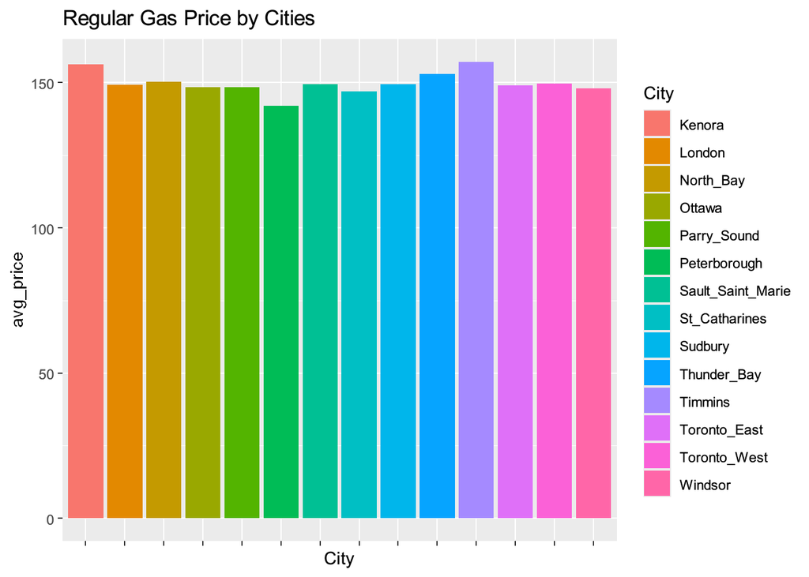

```
##  Ontario_Average Southern_Ontario_Average Northern_Ontario_Average
##  Min.   :106.4   Min.   :105.6            Min.   :112.8
##  1st Qu.:135.9   1st Qu.:135.9            1st Qu.:136.2
##  Median :148.2   Median :147.4            Median :151.6
##  Mean   :149.1   Mean   :148.8            Mean   :151.4
##  3rd Qu.:159.1   3rd Qu.:158.6            3rd Qu.:162.3
##  Max.   :213.8   Max.   :213.7            Max.   :218.0
```

### Section 5: Statistical Inference

To answer our research question on how prices differ across cities, we will compare the Northern Ontario Average price to the Southern Ontario Average price.

#### 5.1 Confidence Interval

We estimate the difference in gas prices (Northern Average - Southern Average) across the available weeks between 2021-2026 for Regular Unleaded Gasoline, Diesel, and Auto Propane.

Average Price Differences: Northern vs. Southern Ontario

| Fuel Type | Mean Difference (cents/litre) | 95% Confidence Interval |
| --- | --- | --- |
| Regular Unleaded Gasoline | 2.57 | (1.85, 3.29) |
| Diesel | 4.30 | (3.82, 4.77) |
| Auto Propane | 19.58 | (18.58, 20.59) |

**Interpretation**:  
Based on data from the last five years, we are 95% confident that the true average difference in fuel prices between Northern and Southern Ontario falls within the following intervals (in cents per litre): **Regular Gas:** 1.85 to 3.29, **Diesel:** 3.82 to 4.77, **Auto Propane:** 18.58 to 20.59

#### 5.2 Hypothesis Testing

To rigorously answer our research question regarding regional price differences, we conducted a paired t-test for each of our three fuel types. We set our significance level at $\alpha = 0.05$.

**Hypotheses:** Let $\mu_d$ represent the true mean difference in weekly fuel prices between Northern and Southern Ontario ($\mu_{North} - \mu_{South}$).

- **Null Hypothesis ($H_0$):** $\mu_d = 0$. There is no true mean difference in fuel prices between Northern and Southern Ontario.
- **Alternative Hypothesis ($H_1$):** $\mu_d \neq 0$. There is a statistically significant mean difference in fuel prices between Northern and Southern Ontario.

**Results:**

Paired T-Test Results: Regional Price Differences

[output not shown]

### Section 6: Bootstrapping

To ensure our findings are robust and not skewed by these potential outliers, we utilize Bootstrapping. By resampling our paired regional price differences 1,000 times with replacement, we can generate a distribution of the mean difference without relying on assumptions of normality.

#### 6.1 Bootstrap Confidence Intervals vs. Classical Intervals

Comparison of Classical and Bootstrapped 95% Confidence Intervals

| Fuel Type | Classical 95% CI (T-Test) | Bootstrap 95% CI |
| --- | --- | --- |
| Regular Unleaded Gasoline | (1.85, 3.29) | (1.85, 3.27) |
| Diesel | (3.82, 4.77) | (3.8, 4.75) |
| Auto Propane | (18.58, 20.59) | (18.65, 20.57) |

#### 6.2 Visualization of Bootstrapped Means

[figure not shown]

#### 6.3 Interpretation

As demonstrated in the comparison table, our non-parametric Bootstrap confidence intervals are nearly identical to the classical parametric intervals calculated in Section 5. Furthermore, the visualized distributions of the resampled means for all three fuel types show clear, bell-shaped curves entirely above zero.

### Section 7: Regression Analysis

In order to better understand the fuel price difference between the cities, we fit a regression model with time and city as predictors. From the weekly fuel price plot in Section 4, we can clearly see the correlation between time and fuel price is non-linear. Thus, we fit a polynomial regression model.

To prevent overfitting, we build the full model of maximum degree 5, and use cross-validation to determine the best degree model. To make sure the models perform well throughout this time period, we use 5-fold cross-validation. This guarantees that every single weekly data point is used for both training and validation.

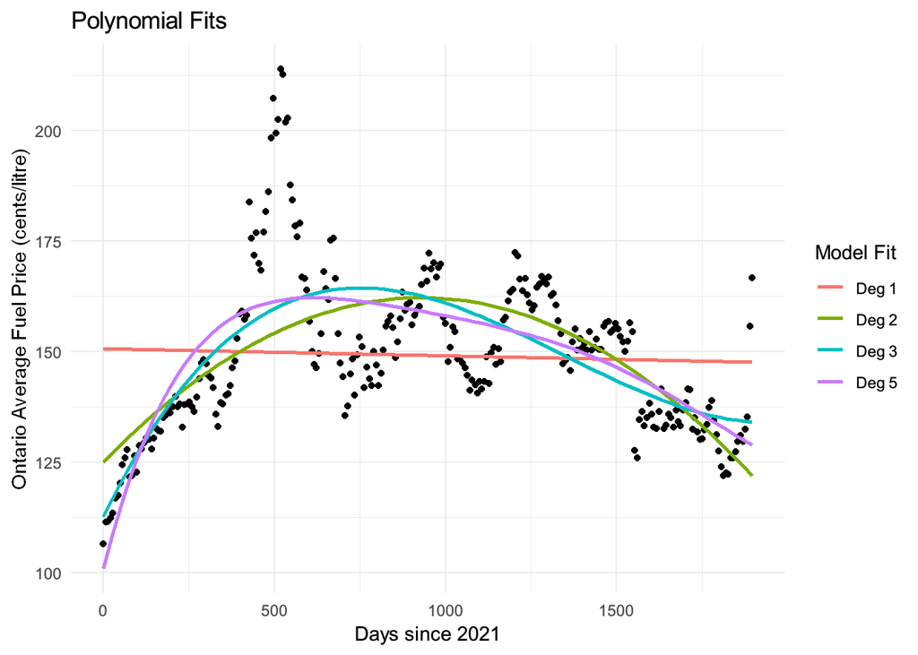

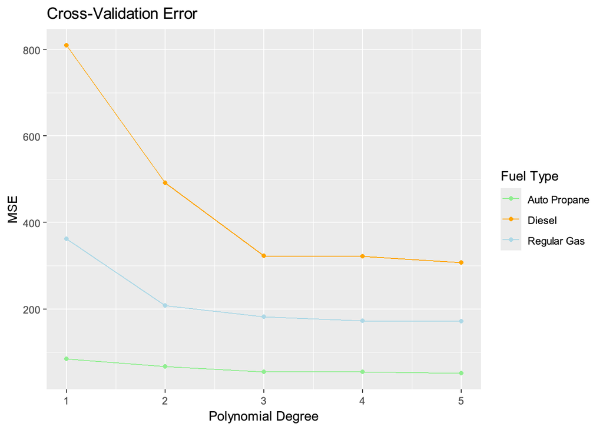

We can see for all fuel types, from degree 1 to degree 3, MSE dropped significantly as the model complexity increases. However, after degree 3, the extra accuracy is marginal. To prevent overfitting, we prefer simpler model given similar accuracy. Thus, we choose degree 3 model as the final model for all fuel types.

We fit the three models, and plot the fitted polynomial regression for regular gas and diesel in Kenora (Baseline), St Catharines and Toronto East to see the fit, and for auto propane in Kenora (Baseline) and Toronto East. We can see that the polynomial regression fits mostly follow the price trends.

```
Call:
lm(formula = Price ~ City + poly(Time_Index, 3), data = regular_gas_data_reg)

Residuals:
    Min      1Q  Median      3Q     Max
-36.148  -8.387  -1.666   6.863  60.144

Coefficients:
                       Estimate Std. Error t value Pr(>|t|)
(Intercept)            156.3092     0.8155 191.674  < 2e-16 ***
CityLondon              -7.1397     1.1533  -6.191 6.63e-10 ***
CityNorth_Bay           -6.0956     1.1533  -5.285 1.32e-07 ***
CityOttawa              -7.9864     1.1533  -6.925 5.10e-12 ***
CityParry_Sound         -7.8309     1.1533  -6.790 1.30e-11 ***
CityPeterborough       -14.3669     1.1533 -12.457  < 2e-16 ***
CitySault_Saint_Marie   -6.9379     1.1533  -6.016 1.96e-09 ***
CitySt_Catharines       -9.3978     1.1533  -8.149 4.95e-16 ***
CitySudbury             -6.8945     1.1533  -5.978 2.47e-09 ***
CityThunder_Bay         -3.2702     1.1533  -2.836   0.0046 **
CityTimmins              0.8665     1.1533   0.751   0.4525
CityToronto_East        -7.2460     1.1533  -6.283 3.70e-10 ***
CityToronto_West        -6.7298     1.1533  -5.835 5.82e-09 ***
CityWindsor             -8.2640     1.1533  -7.166 9.26e-13 ***
poly(Time_Index, 3)1  -142.2913    13.4495 -10.580  < 2e-16 ***
poly(Time_Index, 3)2  -763.4847    13.4495 -56.767  < 2e-16 ***
poly(Time_Index, 3)3   310.1864    13.4495  23.063  < 2e-16 ***
---
Signif. codes:  0 '***' 0.001 '**' 0.01 '*' 0.05 '.' 0.1 ' ' 1

Residual standard error: 13.45 on 3791 degrees of freedom
Multiple R-squared:  0.5223,    Adjusted R-squared:  0.5203
F-statistic: 259.1 on 16 and 3791 DF,  p-value: < 2.2e-16
```

```
Call:
lm(formula = Price ~ City + poly(Time_Index, 3), data = diesel_data_reg)

Residuals:
    Min      1Q  Median      3Q     Max
-38.995 -11.422  -1.456   9.439  67.411

Coefficients:
                        Estimate Std. Error t value Pr(>|t|)
(Intercept)             167.1912     1.0852 154.067  < 2e-16 ***
CityLondon               -8.4243     1.5347  -5.489 4.30e-08 ***
CityNorth_Bay            -5.1445     1.5347  -3.352 0.000810 ***
CityOttawa               -5.4596     1.5347  -3.557 0.000379 ***
CityParry_Sound          -7.4728     1.5347  -4.869 1.17e-06 ***
CityPeterborough         -8.7099     1.5347  -5.675 1.49e-08 ***
CitySault_Saint_Marie     0.7368     1.5347   0.480 0.631202
CitySt_Catharines        -9.1967     1.5347  -5.993 2.26e-09 ***
CitySudbury              -6.7386     1.5347  -4.391 1.16e-05 ***
CityThunder_Bay          -1.5261     1.5347  -0.994 0.320089
CityTimmins              -1.3246     1.5347  -0.863 0.388122
CityToronto_East         -8.1949     1.5347  -5.340 9.85e-08 ***
CityToronto_West         -7.3290     1.5347  -4.776 1.86e-06 ***
CityWindsor              -9.6544     1.5347  -6.291 3.52e-10 ***
poly(Time_Index, 3)1      4.3461    17.8974   0.243 0.808146
poly(Time_Index, 3)2  -1096.4363    17.8974 -61.262  < 2e-16 ***
poly(Time_Index, 3)3    798.5142    17.8974  44.616  < 2e-16 ***
---
Signif. codes:  0 '***' 0.001 '**' 0.01 '*' 0.05 '.' 0.1 ' ' 1

Residual standard error: 17.9 on 3791 degrees of freedom
Multiple R-squared:  0.6083,    Adjusted R-squared:  0.6066
F-statistic: 367.9 on 16 and 3791 DF,  p-value: < 2.2e-16
```

```
Call:
lm(formula = Price ~ City + poly(Time_Index, 3), data = auto_propane_data_reg)

Residuals:
     Min       1Q   Median       3Q      Max
-21.1641  -5.4277   0.6259   4.3352  29.5266

Coefficients:
                      Estimate Std. Error t value Pr(>|t|)
(Intercept)           114.3491     0.4465 256.100   <2e-16 ***
CityLondon            -14.2537     0.6309 -22.594   <2e-16 ***
CityOttawa             13.0129     0.6309  20.627   <2e-16 ***
CityThunder_Bay        -1.2574     0.6309  -1.993   0.0464 *
CityToronto_East      -35.7780     0.6309 -56.712   <2e-16 ***
CityToronto_West      -28.8232     0.6309 -45.688   <2e-16 ***
CityWindsor           -22.9423     0.6309 -36.366   <2e-16 ***
poly(Time_Index, 3)1  211.6931     7.3503  28.801   <2e-16 ***
poly(Time_Index, 3)2 -181.3465     7.3503 -24.672   <2e-16 ***
poly(Time_Index, 3)3  156.6610     7.3503  21.313   <2e-16 ***
---
Signif. codes:  0 '***' 0.001 '**' 0.01 '*' 0.05 '.' 0.1 ' ' 1

Residual standard error: 7.35 on 1893 degrees of freedom
Multiple R-squared:  0.8556,    Adjusted R-squared:  0.8549
F-statistic:  1246 on 9 and 1893 DF,  p-value: < 2.2e-16
```

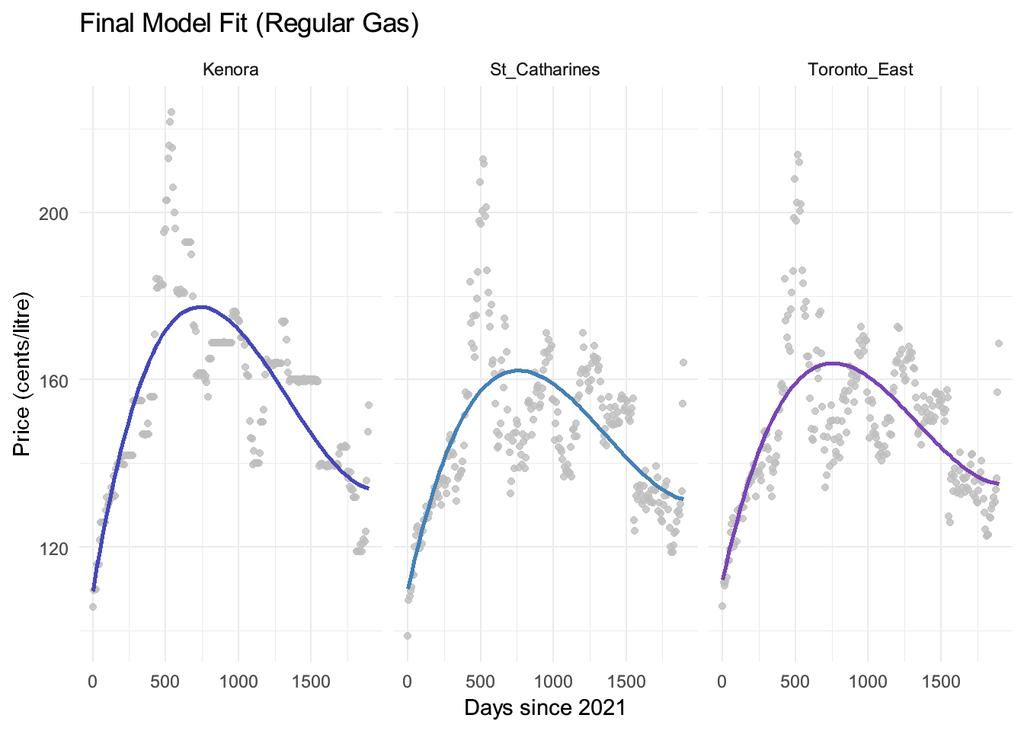

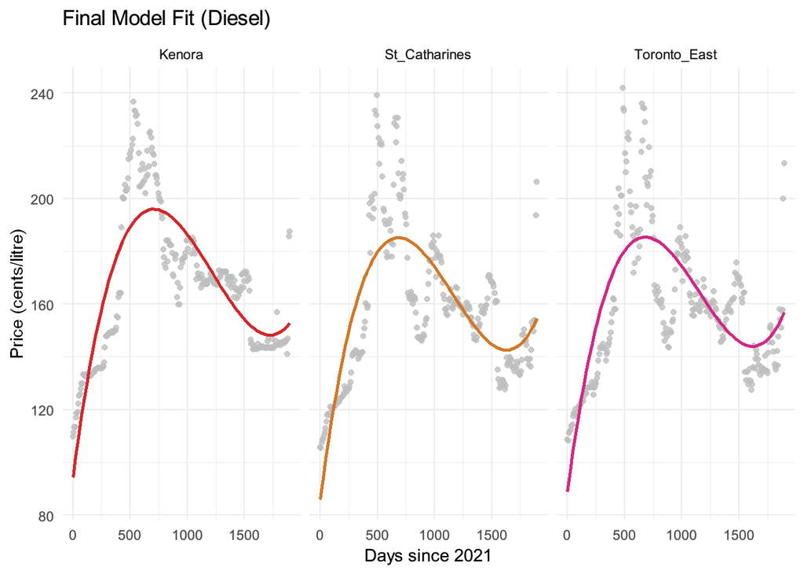

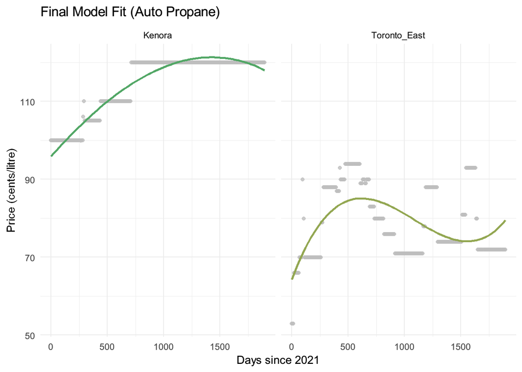

**Model Interpretation:**  
- Kenora is the baseline city for all three models. We noticed that most of the city coefficients are negative, which suggests Kenora is one of the most expensive cities in Ontario.

**Regular Gas:** - Peterborough has the lowest regular gas price average, approximately 14.37 cents less than baseline Kenora.  
- The p-value for CityTimmins is 0.4525 > 0.05, thus there is no significant difference in regular gas price between Kenora and Timmins. All other predictors are significant.  
- Adjusted R-squared: 0.5203. This suggests approximately 52.0% of variance in regular gas price can be explained by this model.

**Diesel:** - Windsor has the lowest diesel price average, approximately 9.65 cents less than baseline Kenora.  
- The p-values for CitySault_Saint_Marie (0.6312), CityThunder_Bay (0.3201), and CityTimmins (0.3881) are all > 0.05. Thus, there is no significant difference in diesel price between Kenora and these Northern cities.  
- Adjusted R-squared: 0.6066. This suggests approximately 60.7% of the variance in diesel price can be explained by this model.

**Auto Propane:** - Toronto East has the lowest auto propane price average, approximately 35.78 cents less than baseline Kenora.  
- Unlike the other fuel types, Ottawa has a significantly higher price than the baseline, averaging 13.01 cents more per litre than Kenora. - All City predictors are significant (p < 0.05).  
- Adjusted R-squared: 0.8549. This suggests approximately 85.5% of the variance in auto propane price can be explained by this model.

To make these results easier to understand, we extract the city coefficients from all three models. We plot the difference of each city with baseline Kenora.

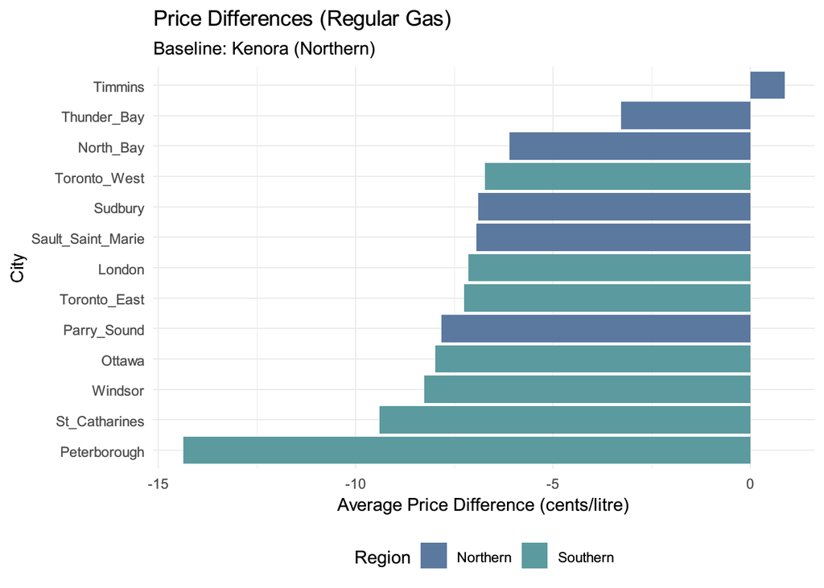

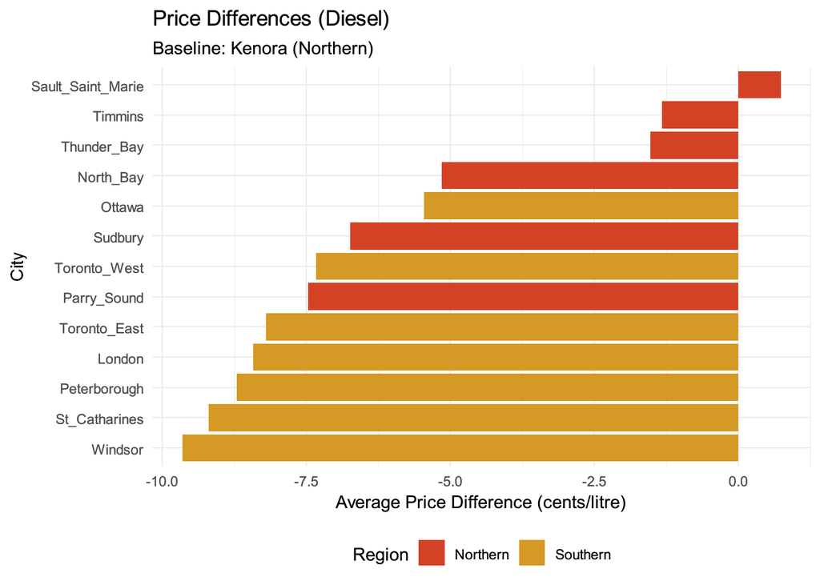

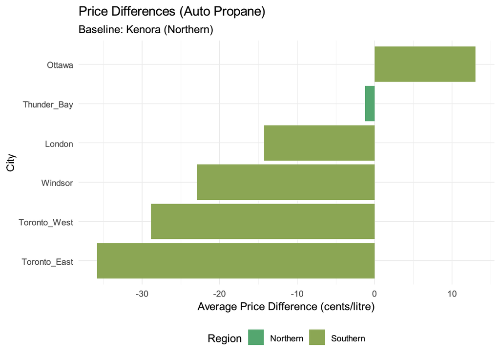

We can see that for regular gas and diesel, the northern cities are mostly more expensive than southern cities. For auto propane, the general trend continues, except for Ottawa (Southern) being noticeably more expensive than the baseline Kenora (Northern).

### Section 8: Conclusion

This study investigated fuel price differences among Ontario cities from 2021 to 2026, analyzing regular gasoline, diesel, and auto propane.  
First, we noticed northern cities have higher regular gas prices than southern cities from the summary statistics. Then, we used 95% confidence intervals, paired t-tests, and bootstrap resampling to prove that fuel prices in Northern Ontario are significantly higher than in Southern Ontario. Finally, we developed 5-fold cross-validated polynomial regression models to quantify the differences between cities. The models confirmed that the fuel price in Southern Ontario is significantly cheaper than Northern Ontario, and the difference in Auto Propane is significantly larger than Regular Gas and Diesel.

### Section 9: Appendix

```r
library(tidyverse)
library(dplyr)
library(lubridate)
library(knitr)
library(ggplot2)

### Section 3: Data Preparation/Cleaning
# Get the data
raw_data = read.csv("data/fueltypesall.csv")
# Rename the columns to full English
d = raw_data %>%
  rename(Toronto_West = Toronto.West.Ouest, Toronto_East = Toronto.East.Est,
    St_Catharines = St..Catharine.s,Sault_Saint_Marie = Sault.Saint.Marie,
    Thunder_Bay = Thunder.Bay,North_Bay = North.Bay,Parry_Sound = Parry.Sound,
    Ontario_Average = Ontario.Average.Moyenne.provinciale,
    Southern_Ontario_Average = Southern.Average.Moyenne.du.sud.de.l.Ontario,
    Northern_Ontario_Average = Northern.Average.Moyenne.du.nord.de.l.Ontario,
    Fuel_Type = Fuel.Type)


# Drop the column Type.de.carburant
d = d %>% select(!Type.de.carburant)
# Convert 0 values to NA
d = d %>% mutate(across(where(is.numeric), ~ na_if(., 0)))
# Change the Date column type from char to date
d = d %>% mutate(Date = as.Date(Date))

# Separate the data set into the six fuel categories and drop the Fuel_Type
# column for each new data set
regular_gas_data = d %>% filter(Fuel_Type == "Regular Unleaded Gasoline") %>% select(!Fuel_Type)

diesel_data = d %>% filter(Fuel_Type == "Diesel") %>% select(!Fuel_Type)

auto_propane_data = d %>% filter(Fuel_Type == "Auto Propane") %>% select(!Fuel_Type)

regular_gas_data_reg = regular_gas_data %>%select(Date, Ottawa, Windsor, London, Peterborough, Sudbury, North_Bay, Parry_Sound, Sault_Saint_Marie, St_Catharines, Thunder_Bay, Toronto_East, Toronto_West, Timmins, Kenora) %>%pivot_longer(cols = -Date, names_to = "City", values_to = "Price") %>%drop_na() %>%mutate(Time_Index = as.numeric(Date - min(Date)))

# Data Cleaning for Regression Model
diesel_data_reg = diesel_data %>% select(Date, Ottawa, Windsor, London, Peterborough, Sudbury, North_Bay, Parry_Sound, Sault_Saint_Marie, St_Catharines, Thunder_Bay, Toronto_East, Toronto_West, Timmins, Kenora) %>%
  pivot_longer(cols = -Date, names_to = "City", values_to = "Price") %>%
  drop_na() %>% mutate(Time_Index = as.numeric(Date - min(Date)))

auto_propane_data_reg = auto_propane_data %>%
  select(Date, Ottawa, Windsor, London, Thunder_Bay, Toronto_East, Toronto_West,
  Kenora) %>%pivot_longer(cols = -Date, names_to = "City", values_to = "Price") %>%drop_na() %>% mutate(Time_Index = as.numeric(Date - min(Date)))


### Section 4: Exploratory Data Analysis
d %>% filter(Fuel_Type %in% c("Regular Unleaded Gasoline", "Diesel", "Auto Propane")) %>% ggplot(aes(x = Date, y = Ontario_Average, color = Fuel_Type)) + geom_line() + labs(title = "Weekly Fuel Prices in Ontario by Fuel Type",x = "Week", y = "Average Fuel Price (cents/litre)", color = "Fuel Type")

# Next we compare the average prices by city
regular_gas_data_reg %>% group_by(City) %>%
  summarise(avg_price = mean(Price, na.rm = TRUE)) %>%
  ggplot(aes(x = City, y = avg_price, fill = City)) +
  geom_col() + theme(axis.text.x = element_blank()) +
  labs(title = "Regular Gas Price by Cities")

### Section 5: Statistical Inference

# REGULAR GASOLINE
regional_compare_gas = regular_gas_data %>%
  filter(Date >= as.Date("2021-01-01")) %>%
  select(Date, Northern_Ontario_Average, Southern_Ontario_Average) %>%
  drop_na() %>%
  mutate(Reg_Diff = Northern_Ontario_Average - Southern_Ontario_Average)

t_test_gas = t.test(regional_compare_gas$Northern_Ontario_Average,
                    regional_compare_gas$Southern_Ontario_Average,
                    paired = TRUE)
mean_diff_gas = t_test_gas$estimate
ci_lower_gas = t_test_gas$conf.int[1]
ci_upper_gas = t_test_gas$conf.int[2]
p_val_gas = t_test_gas$p.value

# DIESEL
regional_compare_diesel = diesel_data %>%
  filter(Date >= as.Date("2021-01-01")) %>%
  select(Date, Northern_Ontario_Average, Southern_Ontario_Average) %>%
  drop_na() %>%
  mutate(Reg_Diff = Northern_Ontario_Average - Southern_Ontario_Average)

t_test_diesel = t.test(regional_compare_diesel$Northern_Ontario_Average,
                       regional_compare_diesel$Southern_Ontario_Average,
                       paired = TRUE)
mean_diff_diesel = t_test_diesel$estimate
ci_lower_diesel = t_test_diesel$conf.int[1]
ci_upper_diesel = t_test_diesel$conf.int[2]
p_val_diesel = t_test_diesel$p.value

# AUTO PROPANE
regional_compare_propane = auto_propane_data %>%
  filter(Date >= as.Date("2021-01-01")) %>%
  select(Date, Northern_Ontario_Average, Southern_Ontario_Average) %>%
  drop_na() %>%
  mutate(Reg_Diff = Northern_Ontario_Average - Southern_Ontario_Average)

t_test_propane = t.test(regional_compare_propane$Northern_Ontario_Average,
                        regional_compare_propane$Southern_Ontario_Average,
                        paired = TRUE)
mean_diff_propane = t_test_propane$estimate
ci_lower_propane = t_test_propane$conf.int[1]
ci_upper_propane = t_test_propane$conf.int[2]
p_val_propane = t_test_propane$p.value


summary_table = data.frame( "Fuel Type" = c("Regular Unleaded Gasoline", "Diesel", "Auto Propane"  ), "Mean Difference (cents/litre)" = c(round(mean_diff_gas, 2), round(mean_diff_diesel, 2),round(mean_diff_propane, 2)),
  "95% Confidence Interval" = c(paste0("(", round(ci_lower_gas, 2), ", ", round(ci_upper_gas, 2), ")"),paste0("(", round(ci_lower_diesel, 2), ", ", round(ci_upper_diesel, 2),")"),paste0("(", round(ci_lower_propane, 2), ", ", round(ci_upper_propane, 2),")")),check.names = FALSE)

kable(summary_table,
      caption = "Average Price Differences: Northern vs. Southern Ontario",
      align = c("c", "c", "c"))

# Hypothesis Testing results
ht_table = data.frame("Fuel Type" = c("Regular Unleaded Gasoline","Diesel", "Auto Propane"),"p-value" = c(format.pval(p_val_gas, digits = 3, eps = 0.001),
    format.pval(p_val_diesel, digits = 3, eps = 0.001),
    format.pval(p_val_propane, digits = 3, eps = 0.001)),check.names = FALSE)

kable(ht_table, caption = "Paired T-Test Results: Regional Price Differences",align = c("l", "c", "c"))

### Section 6: Bootstrapping

set.seed(57)
B = 1000

get_boot_ci = function(df) {
  boot_function = function() {
    boot_data = df %>% slice_sample(n = nrow(df), replace = TRUE)
    boot_mean = boot_data %>% summarize(cal.s = mean(Reg_Diff, na.rm = TRUE))
    return(boot_mean[1,1])
  }
  boot_means = replicate(B, boot_function())
  ci = quantile(boot_means, probs = c(0.025, 0.975))
  return(c(lower = ci[1], upper = ci[2]))
}
boot_gas = get_boot_ci(regional_compare_gas)
boot_diesel = get_boot_ci(regional_compare_diesel)
boot_propane = get_boot_ci(regional_compare_propane)
```

```r
boot_table = data.frame(
  "Fuel Type" = c("Regular Unleaded Gasoline", "Diesel", "Auto Propane"),
  "Classical 95% CI (T-Test)" = c(
    paste0("(", round(ci_lower_gas, 2), ", ", round(ci_upper_gas, 2), ")"),
    paste0("(", round(ci_lower_diesel, 2), ", ",  round(ci_upper_diesel, 2), ")"),paste0("(", round(ci_lower_propane, 2), ", ", round(ci_upper_propane, 2), ")")),"Bootstrap 95% CI" = c(paste0("(", round(boot_gas["lower.2.5%"], 2), ", ",
           round(boot_gas["upper.97.5%"], 2), ")"),
    paste0("(", round(boot_diesel["lower.2.5%"], 2), ", ",
           round(boot_diesel["upper.97.5%"], 2), ")"),
    paste0("(", round(boot_propane["lower.2.5%"], 2), ", ",
           round(boot_propane["upper.97.5%"], 2), ")")),check.names = FALSE)

kable(boot_table, caption =
        "Comparison of Classical and Bootstrapped 95% Confidence Intervals",
      align = c("l", "c", "c"))

# extract the raw means
get_boot_means = function(df) {
  boot_func = function() {
    boot_data = df %>% slice_sample(n = nrow(df), replace = TRUE)
    boot_mean = boot_data %>% summarize(cal.s = mean(Reg_Diff, na.rm = TRUE))
    return(boot_mean[1,1])
  }
  return(replicate(B, boot_func()))
}

# Generates the 1,000 means
boot_means_gas = get_boot_means(regional_compare_gas)
boot_means_diesel = get_boot_means(regional_compare_diesel)
boot_means_propane = get_boot_means(regional_compare_propane)

#Combines into one dataframe
plot_data = data.frame( Fuel_Type = factor( rep(c("Regular Unleaded Gasoline", "Diesel", "Auto Propane"), each = B),levels = c("Regular Unleaded Gasoline", "Diesel", "Auto Propane") ),Means = c(boot_means_gas, boot_means_diesel, boot_means_propane))

#Creates a dataframe for CI
ci_data = data.frame(Fuel_Type = factor(c("Regular Unleaded Gasoline", "Diesel", "Auto Propane"), levels = c("Regular Unleaded Gasoline", "Diesel", "Auto Propane")),Lower = c(boot_gas[1], boot_diesel[1], boot_propane[1]),
  Upper = c(boot_gas[2], boot_diesel[2], boot_propane[2]))

#Plot
ggplot(plot_data, aes(x = Means, fill = Fuel_Type)) +
  geom_histogram(bins = 40, color = "black", linewidth = 0.2, alpha = 0.8,
                 show.legend = FALSE) +
  geom_vline(data = ci_data, aes(xintercept = Lower), color = "red",
             linetype = "dashed", linewidth = .4) +
  geom_vline(data = ci_data, aes(xintercept = Upper), color = "red",
             linetype = "dashed", linewidth = .4) +
  scale_fill_manual(values = c(
    "Regular Unleaded Gasoline" = "steelblue",
    "Diesel" = "darkorange",
    "Auto Propane" = "forestgreen"
  )) +
  facet_wrap(~ Fuel_Type, scales = "free_x", ncol = 3) +
  labs(title = "Bootstrap Distributions of Mean Regional Differences",
    subtitle = "Northern Avg - Southern Avg (1,000 Resamples)",
    x = "Mean Difference (cents/litre)",
    y = "Frequency") +theme_minimal(base_size = 14, base_family = "serif") +
  theme(strip.text = element_text(face = "bold", size = 10))

### Section 7: Regression Analysis
# Visualization on polynomial fitting
plot_data = regular_gas_data %>%
  filter(Date >= as.Date("2021-01-01")) %>%
  mutate(Time_Index = as.numeric(Date - min(Date))) %>%
  drop_na(Ontario_Average)

ggplot(plot_data, aes(x = Time_Index, y = Ontario_Average)) +
  geom_point() +
  geom_smooth(method = "lm", formula = y ~ poly(x, 1),
              aes(color = "Deg 1"), se = FALSE, linewidth = 1) +
  geom_smooth(method = "lm", formula = y ~ poly(x, 2),
              aes(color = "Deg 2"), se = FALSE, linewidth = 1) +
  geom_smooth(method = "lm", formula = y ~ poly(x, 3),
              aes(color = "Deg 3"), se = FALSE, linewidth = 1) +
  geom_smooth(method = "lm", formula = y ~ poly(x, 5),
              aes(color = "Deg 5"), se = FALSE, linewidth = 1) +
  labs(title = "Polynomial Fits",x = "Days since 2021", y = "Ontario Average Fuel Price (cents/litre)", color = "Model Fit") +  theme_minimal()

# Data split
regular = regular_gas_data_reg %>% mutate(group_ind = sample(c(1:5), size = nrow(regular_gas_data_reg), replace = TRUE))

diesel = diesel_data_reg %>% mutate(group_ind = sample(c(1:5), size = nrow(diesel_data_reg), replace = TRUE))

propane = auto_propane_data_reg %>% mutate(group_ind = sample(c(1:5), size = nrow(auto_propane_data_reg), replace = TRUE))

regular_mse = vector()
diesel_mse = vector()
propane_mse = vector()

# Cross Validation
for(d in 1:5) {
  mse_fold = vector()
  for(i in 1:5) {
    train_set = regular %>% filter(group_ind != i)
    validation_set = regular %>% filter(group_ind == i)
    m_train = lm(Price ~ City + poly(Time_Index, d), data = train_set)
    y_hat = predict(m_train, newdata = validation_set)
    mse_fold[i] = mean((validation_set$Price - y_hat)^2, na.rm = TRUE)
  }
  regular_mse[d] = mean(mse_fold)
}

cv_result_regular = data.frame( "Polynomial Degree" = c("Degree 1", "Degree 2", "Degree 3", "Degree 4", "Degree 5"),"Cross-Validated MSE" = regular_mse,check.names = FALSE)

for(d in 1:5) {
  mse_fold = vector()
  for(i in 1:5) {
    train_set = diesel %>% filter(group_ind != i)
    validation_set = diesel %>% filter(group_ind == i)
    m_train = lm(Price ~ City + poly(Time_Index, d), data = train_set)
    y_hat = predict(m_train, newdata = validation_set)
    mse_fold[i] = mean((validation_set$Price - y_hat)^2, na.rm = TRUE)
  }
  diesel_mse[d] = mean(mse_fold)
}

cv_result_diesel = data.frame("Polynomial Degree" = c("Degree 1", "Degree 2", "Degree 3", "Degree 4", "Degree 5"),"Cross-Validated MSE" = diesel_mse,
  check.names = FALSE)

for(d in 1:5) {
  mse_fold = vector()
  for(i in 1:5) {
    train_set = propane %>% filter(group_ind != i)
    validation_set = propane %>% filter(group_ind == i)
    m_train = lm(Price ~ City + poly(Time_Index, d), data = train_set)
    y_hat = predict(m_train, newdata = validation_set)
    mse_fold[i] = mean((validation_set$Price - y_hat)^2, na.rm = TRUE)
  }
  propane_mse[d] = mean(mse_fold)
}

cv_result_propane = data.frame("Polynomial Degree" = c("Degree 1", "Degree 2", "Degree 3", "Degree 4", "Degree 5"),"Cross-Validated MSE" = propane_mse,
  check.names = FALSE)
```

```r
# Summary plot
plot_cv_data = data.frame(Degree = rep(1:5, 3),
  MSE = c(regular_mse, diesel_mse, propane_mse),
  Fuel_Type = rep(c("Regular Gas", "Diesel", "Auto Propane"), each = 5))

ggplot(plot_cv_data, aes(x = Degree, y = MSE, color = Fuel_Type, group = Fuel_Type)) +geom_line() + geom_point() +scale_color_manual(values = c("Regular Gas" = "lightblue", "Diesel" = "orange", "Auto Propane" = "lightgreen")) + labs(title = "Cross-Validation Error",x = "Polynomial Degree",y = "MSE",color = "Fuel Type")

# Final models
regular_fit = lm(Price ~ City + poly(Time_Index, 3), data = regular_gas_data_reg)
diesel_fit = lm(Price ~ City + poly(Time_Index, 3), data = diesel_data_reg)
propane_fit = lm(Price ~ City + poly(Time_Index, 3), data = auto_propane_data_reg)

summary(regular_fit)
summary(diesel_fit)
summary(propane_fit)

# Plot the fitted model for 3 cities, regular gas
plot_cities_1 = c("Kenora", "Toronto_East", "St_Catharines")
plot_data_1 = regular_gas_data_reg %>% filter(City %in% plot_cities_1)

ggplot(plot_data_1, aes(x = Time_Index, y = Price, color = City)) +
  geom_point(color = "grey", alpha = 0.8) +
  geom_smooth(method = "lm", formula = y ~ poly(x, 3), se = FALSE) +
  facet_wrap(~ City) +scale_color_manual(values = c("Kenora" = "#4548B5",
    "Toronto_East" = "#7945B5", "St_Catharines" = "#4581B5")) +
  labs(title = "Final Model Fit (Regular Gas)", x = "Days since 2021",y = "Price (cents/litre)") + theme_minimal() + theme(legend.position = "none")

# Plot the fitted model for 3 cities, diesel
plot_cities_1 = c("Kenora", "Toronto_East", "St_Catharines")
plot_data_2 = diesel_data_reg %>% filter(City %in% plot_cities_1)

ggplot(plot_data_2, aes(x = Time_Index, y = Price, color = City)) +
  geom_point(color = "grey", alpha = 0.8) +  geom_smooth(method = "lm", formula = y ~ poly(x, 3), se = FALSE) + facet_wrap(~ City) +scale_color_manual(values = c("Kenora" = "#D3272C", "Toronto_East" = "#D32783", "St_Catharines" = "#D37727")) + labs(title = "Final Model Fit (Diesel)",  x = "Days since 2021",
    y = "Price (cents/litre)") +theme_minimal() + theme(legend.position = "none")

# Plot the fitted model for 2 cities, auto propane
plot_cities_2 = c("Kenora", "Toronto_East")
plot_data_3 = auto_propane_data_reg %>% filter(City %in% plot_cities_2)

ggplot(plot_data_3, aes(x = Time_Index, y = Price, color = City)) +
  geom_point(color = "grey", alpha = 0.8) +
  geom_smooth(method = "lm", formula = y ~ poly(x, 3), se = FALSE) +
  facet_wrap(~ City) +scale_color_manual(values = c("Kenora" = "#52A766",     "Toronto_East" = "#93A752")) +nlabs(title = "Final Model Fit (Auto Propane)",
    x = "Days since 2021",y = "Price (cents/litre)") +theme_minimal() + theme(legend.position = "none")

r_coefs = as.data.frame(summary(regular_fit)$coefficients)
r_coefs$Term = rownames(r_coefs)

# Create a new column for cities in North and South
r_plot = r_coefs %>%filter(grepl("City", Term)) %>% mutate(City = gsub("City", "", Term)) %>% mutate(Region = ifelse(City %in% c("Thunder_Bay", "Timmins", "Sudbury", "North_Bay", "Sault_Saint_Marie","Parry_Sound"), "Northern", "Southern"))

ggplot(r_plot, aes(x = reorder(City, Estimate), y = Estimate, fill = Region)) + geom_col() + coord_flip() + scale_fill_manual(values = c("Northern" = "#5B789F", "Southern" = "#5B9A9F")) + labs(title = "Price Differences (Regular Gas)", subtitle = "Baseline: Kenora (Northern)", x = "City", y = "Average Price Difference (cents/litre)") +
  theme_minimal() + theme(legend.position = "bottom")

d_coefs = as.data.frame(summary(diesel_fit)$coefficients)
d_coefs$Term = rownames(d_coefs)

d_plot = d_coefs %>%filter(grepl("City", Term)) %>% mutate(City = gsub("City", "", Term)) %>% mutate(Region = ifelse(City %in% c("Thunder_Bay", "Timmins", "Sudbury", "North_Bay", "Sault_Saint_Marie","Parry_Sound"), "Northern", "Southern"))

ggplot(d_plot, aes(x = reorder(City, Estimate), y = Estimate, fill = Region)) + geom_col() + coord_flip() + scale_fill_manual(values = c("Northern" = "#D44225", "Southern" = "#D49A25")) + labs(title = "Price Differences (Diesel)", subtitle = "Baseline: Kenora (Northern)", x = "City", y = "Average Price Difference (cents/litre)") + theme_minimal() + theme(legend.position = "bottom")

p_coefs = as.data.frame(summary(propane_fit)$coefficients)
p_coefs$Term = rownames(p_coefs)

p_plot = p_coefs %>%filter(grepl("City", Term)) %>% mutate(City = gsub("City", "", Term)) %>% mutate(Region = ifelse(City %in% c("Thunder_Bay", "Timmins", "Sudbury", "North_Bay", "Sault_Saint_Marie","Parry_Sound"), "Northern", "Southern"))

ggplot(p_plot, aes(x = reorder(City, Estimate), y = Estimate, fill = Region)) + geom_col() + coord_flip() + scale_fill_manual(values = c("Northern" = "#54A66F", "Southern" = "#8BA654")) + labs(title = "Price Differences (Auto Propane)", subtitle = "Baseline: Kenora (Northern)", x = "City", y = "Average Price Difference (cents/litre)") + theme_minimal() + theme(legend.position = "bottom")
```